# Exploratory Data Analysis

Authors: Somya Srivastava and Sowmya Sri P

```r
library(tidyverse)
library(Hmisc)
```

```r
library(ggplot2)
library(ggstatsplot)
```

# Introduction

### Dataset used: [Predict Test Scores of students](https://www.kaggle.com/kwadwoofosu/predict-test-scores-of-students)

### Link to github repository:- https://github.com/1NT18IS155/Exploratory-Data-Analysis

We have explored the data in various ways, and on most of the columns separately as well, using tidyverse. We have visualised the same using various graphs using ggplot2 mostly. We have further visualised the correlation between the pre test scores of students vs the post test scores, and have also plotted a best-fit line for same. Using this, we can even predict the approximate marks a student will score post test, if pre test scores are known.

Firstly, we shall be loading our data set in the R-Studio project environment using the *read.csv* command.  
Using the **head()** function, we can view the first few rows of the dataset, where **kable()** function helps us to view it in a concise format.

```r
mydata = read.csv("./test_scores.csv")
head(mydata) %>% knitr::kable()
```

| school | school_setting | school_type | classroom | teaching_method | n_student | student_id | gender | lunch | pretest | posttest |
| --- | --- | --- | --- | --- | --- | --- | --- | --- | --- | --- |
| ANKYI | Urban | Non-public | 6OL | Standard | 20 | 2FHT3 | Female | Does not qualify | 62 | 72 |
| ANKYI | Urban | Non-public | 6OL | Standard | 20 | 3JIVH | Female | Does not qualify | 66 | 79 |
| ANKYI | Urban | Non-public | 6OL | Standard | 20 | 3XOWE | Male | Does not qualify | 64 | 76 |
| ANKYI | Urban | Non-public | 6OL | Standard | 20 | 556O0 | Female | Does not qualify | 61 | 77 |
| ANKYI | Urban | Non-public | 6OL | Standard | 20 | 74LOE | Male | Does not qualify | 64 | 76 |
| ANKYI | Urban | Non-public | 6OL | Standard | 20 | 7YZO8 | Female | Does not qualify | 66 | 74 |

We can get an idea of over all dataset using the following functions:

- **str()** - It states the dimensions of the dataset used, and its datatype. In this case we have a _2133*11_ dimensioned data, of *data.frame* type.It also gives the names of all columns, their datatypes and a few of the values from respective columns.
- **summary()** - It gives us an idea about the data in each column. For categorical columns, it gives name,length,class and datatype, whereas for numerical columns, it gives insights on the quartile values and ranges, and the mean, median, minimum and maximum values in the respective columns.
- **class()** - It gives the datatype of the data which is provided to it.
- **length()** - It gives the number of columns in the data.
- **names()** - It gives the names of all the columns.

```r
str(mydata)
```

```
## 'data.frame':    2133 obs. of  11 variables:
##  $ school         : chr  "ANKYI" "ANKYI" "ANKYI" "ANKYI" ...
##  $ school_setting : chr  "Urban" "Urban" "Urban" "Urban" ...
##  $ school_type    : chr  "Non-public" "Non-public" "Non-public" "Non-public" ...
##  $ classroom      : chr  "6OL" "6OL" "6OL" "6OL" ...
##  $ teaching_method: chr  "Standard" "Standard" "Standard" "Standard" ...
##  $ n_student      : num  20 20 20 20 20 20 20 20 20 20 ...
##  $ student_id     : chr  "2FHT3" "3JIVH" "3XOWE" "556O0" ...
##  $ gender         : chr  "Female" "Female" "Male" "Female" ...
##  $ lunch          : chr  "Does not qualify" "Does not qualify" "Does not qualify" "Does not qualify" ...
##  $ pretest        : num  62 66 64 61 64 66 63 63 64 61 ...
##  $ posttest       : num  72 79 76 77 76 74 75 72 77 72 ...
```

```r
summary(mydata)
```

```
##     school          school_setting     school_type         classroom
##  Length:2133        Length:2133        Length:2133        Length:2133
##  Class :character   Class :character   Class :character   Class :character
##  Mode  :character   Mode  :character   Mode  :character   Mode  :character
##
##
##
##  teaching_method      n_student     student_id           gender
##  Length:2133        Min.   :14.0   Length:2133        Length:2133
##  Class :character   1st Qu.:20.0   Class :character   Class :character
##  Mode  :character   Median :22.0   Mode  :character   Mode  :character
##                     Mean   :22.8
##                     3rd Qu.:27.0
##                     Max.   :31.0
##     lunch              pretest         posttest
##  Length:2133        Min.   :22.00   Min.   : 32.0
##  Class :character   1st Qu.:44.00   1st Qu.: 56.0
##  Mode  :character   Median :56.00   Median : 68.0
##                     Mean   :54.96   Mean   : 67.1
##                     3rd Qu.:65.00   3rd Qu.: 77.0
##                     Max.   :93.00   Max.   :100.0
```

```r
class(mydata)
```

```
## [1] "data.frame"
```

```r
length(mydata)
```

```
## [1] 11
```

```r
names(mydata)
```

```
##  [1] "school"          "school_setting"  "school_type"     "classroom"
##  [5] "teaching_method" "n_student"       "student_id"      "gender"
##  [9] "lunch"           "pretest"         "posttest"
```

# School

We are grouping the dataset by school names to find the number of students studying for each school.

```r
school_count <- group_by(mydata,school) %>% count()
school_count
```

```
## # A tibble: 23 x 2
## # Groups:   school [23]
##    school     n
##    <chr>  <int>
##  1 ANKYI     41
##  2 CCAAW    109
##  3 CIMBB     74
##  4 CUQAM    107
##  5 DNQDD    122
##  6 FBUMG     46
##  7 GJJHK    118
##  8 GOKXL     64
##  9 GOOBU    158
## 10 IDGFP     94
## # ... with 13 more rows
```

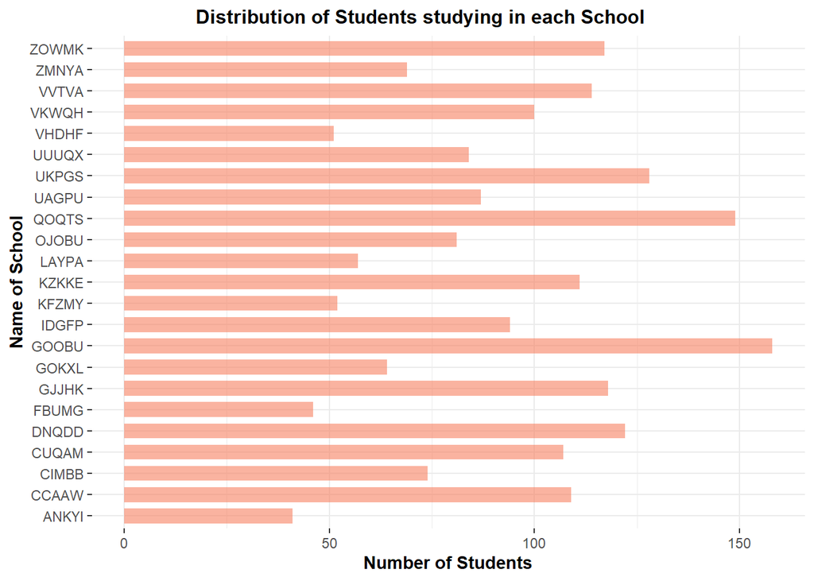

```r
school_count %>% ggplot(aes(x=school, y=n)) +
  geom_bar(stat="identity", fill= "#f68060", alpha=0.6, width=0.7) +
  coord_flip() +
  theme_ggstatsplot() +
  labs(y="Number of Students", x="Name of School", title = "                   Distribution of Students studying in each School")
```

We can infer from the bar plot that a school named “GOOBU” has the most students, whereas a school named “ANKYI” has the least number of students. This can be verified from following code cells, where we have arranged the schools in an ascending number of the count of students studying in them, and extracted the school name and count of the ones having minimum and maximum number of students.

```r
class(school_count)
```

```
## [1] "grouped_df" "tbl_df"     "tbl"        "data.frame"
```

```r
count(mydata,school) %>% arrange(n) %>% head(1)
```

```
##   school  n
## 1  ANKYI 41
```

```r
count(mydata,school) %>% arrange(n) %>% tail(1)
```

```
##    school   n
## 23  GOOBU 158
```

Here, we have displayed the data of all the students who are studying in a particular school named “ANKYI”.

```r
mydata %>% filter(school == "ANKYI") %>% knitr::kable()
```

| school | school_setting | school_type | classroom | teaching_method | n_student | student_id | gender | lunch | pretest | posttest |
| --- | --- | --- | --- | --- | --- | --- | --- | --- | --- | --- |
| ANKYI | Urban | Non-public | 6OL | Standard | 20 | 2FHT3 | Female | Does not qualify | 62 | 72 |
| ANKYI | Urban | Non-public | 6OL | Standard | 20 | 3JIVH | Female | Does not qualify | 66 | 79 |
| ANKYI | Urban | Non-public | 6OL | Standard | 20 | 3XOWE | Male | Does not qualify | 64 | 76 |
| ANKYI | Urban | Non-public | 6OL | Standard | 20 | 556O0 | Female | Does not qualify | 61 | 77 |
| ANKYI | Urban | Non-public | 6OL | Standard | 20 | 74LOE | Male | Does not qualify | 64 | 76 |
| ANKYI | Urban | Non-public | 6OL | Standard | 20 | 7YZO8 | Female | Does not qualify | 66 | 74 |
| ANKYI | Urban | Non-public | 6OL | Standard | 20 | 9KMZD | Male | Does not qualify | 63 | 75 |
| ANKYI | Urban | Non-public | 6OL | Standard | 20 | 9USQK | Female | Does not qualify | 63 | 72 |
| ANKYI | Urban | Non-public | 6OL | Standard | 20 | CS5QP | Male | Does not qualify | 64 | 77 |
| ANKYI | Urban | Non-public | 6OL | Standard | 20 | D6HT8 | Female | Does not qualify | 61 | 72 |
| ANKYI | Urban | Non-public | 6OL | Standard | 20 | DZMKU | Male | Does not qualify | 61 | 73 |
| ANKYI | Urban | Non-public | 6OL | Standard | 20 | FH7B9 | Male | Does not qualify | 64 | 74 |
| ANKYI | Urban | Non-public | 6OL | Standard | 20 | JI9VG | Male | Does not qualify | 66 | 78 |
| ANKYI | Urban | Non-public | 6OL | Standard | 20 | JQM2W | Female | Does not qualify | 60 | 71 |
| ANKYI | Urban | Non-public | 6OL | Standard | 20 | MEUC4 | Female | Does not qualify | 64 | 77 |
| ANKYI | Urban | Non-public | 6OL | Standard | 20 | R4U8H | Male | Does not qualify | 64 | 73 |
| ANKYI | Urban | Non-public | 6OL | Standard | 20 | TH7KI | Male | Does not qualify | 63 | 70 |
| ANKYI | Urban | Non-public | 6OL | Standard | 20 | U1FV7 | Male | Does not qualify | 67 | 73 |
| ANKYI | Urban | Non-public | 6OL | Standard | 20 | WC5I6 | Female | Does not qualify | 63 | 71 |
| ANKYI | Urban | Non-public | 6OL | Standard | 20 | ZBQ4T | Male | Does not qualify | 64 | 73 |
| ANKYI | Urban | Non-public | ZNS | Standard | 21 | 0CRO6 | Male | Does not qualify | 60 | 68 |
| ANKYI | Urban | Non-public | ZNS | Standard | 21 | 1QMDI | Male | Does not qualify | 60 | 70 |
| ANKYI | Urban | Non-public | ZNS | Standard | 21 | 3CFUK | Male | Does not qualify | 57 | 66 |
| ANKYI | Urban | Non-public | ZNS | Standard | 21 | 447O0 | Male | Does not qualify | 57 | 70 |
| ANKYI | Urban | Non-public | ZNS | Standard | 21 | 4IDEM | Female | Qualifies for reduced/free lunch | 56 | 65 |
| ANKYI | Urban | Non-public | ZNS | Standard | 21 | 5UQNP | Male | Does not qualify | 58 | 67 |
| ANKYI | Urban | Non-public | ZNS | Standard | 21 | AV95M | Female | Does not qualify | 60 | 70 |
| ANKYI | Urban | Non-public | ZNS | Standard | 21 | BX6I6 | Female | Does not qualify | 60 | 67 |
| ANKYI | Urban | Non-public | ZNS | Standard | 21 | EYFXR | Male | Does not qualify | 54 | 63 |
| ANKYI | Urban | Non-public | ZNS | Standard | 21 | FFC9M | Male | Does not qualify | 60 | 75 |
| ANKYI | Urban | Non-public | ZNS | Standard | 21 | GGT4A | Male | Does not qualify | 58 | 66 |
| ANKYI | Urban | Non-public | ZNS | Standard | 21 | HRZOJ | Female | Does not qualify | 66 | 71 |
| ANKYI | Urban | Non-public | ZNS | Standard | 21 | IFC62 | Male | Does not qualify | 60 | 76 |
| ANKYI | Urban | Non-public | ZNS | Standard | 21 | LLQI3 | Female | Does not qualify | 59 | 69 |
| ANKYI | Urban | Non-public | ZNS | Standard | 21 | OCJE3 | Female | Does not qualify | 57 | 69 |
| ANKYI | Urban | Non-public | ZNS | Standard | 21 | OGW1F | Female | Does not qualify | 60 | 68 |
| ANKYI | Urban | Non-public | ZNS | Standard | 21 | Q5QRY | Female | Does not qualify | 61 | 71 |
| ANKYI | Urban | Non-public | ZNS | Standard | 21 | TJRIV | Female | Does not qualify | 61 | 66 |
| ANKYI | Urban | Non-public | ZNS | Standard | 21 | U24U5 | Female | Does not qualify | 59 | 69 |
| ANKYI | Urban | Non-public | ZNS | Standard | 21 | VKX2N | Female | Does not qualify | 62 | 72 |
| ANKYI | Urban | Non-public | ZNS | Standard | 21 | ZTROF | Male | Does not qualify | 60 | 66 |

We have calculated the mean of the pretest and posttest scores of all the students belonging to each school.

```r
mean_school <- mydata %>% select(school,pretest,posttest) %>% group_by(school) %>% summarise(pretest_mean=mean(pretest), posttest_mean=mean(posttest))
mean_school
```

```
## # A tibble: 23 x 3
##    school pretest_mean posttest_mean
##    <chr>         <dbl>         <dbl>
##  1 ANKYI          61.3          71.4
##  2 CCAAW          64.6          78.1
##  3 CIMBB          65.1          76.9
##  4 CUQAM          53.9          65.6
##  5 DNQDD          54.3          66.6
##  6 FBUMG          62.9          78.6
##  7 GJJHK          53.2          65.0
##  8 GOKXL          50.8          65.0
##  9 GOOBU          38.2          49.6
## 10 IDGFP          75.2          87.2
## # ... with 13 more rows
```

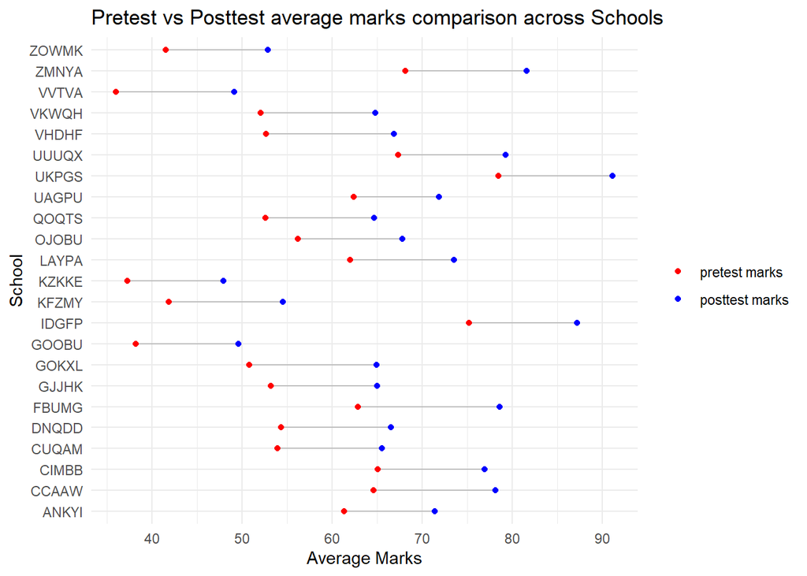

```r
mean_school %>% ggplot() +
  geom_segment(aes(x=school,xend=school,y=pretest_mean,yend=posttest_mean),color="grey") +
  geom_point(aes(x=school,y=pretest_mean,color="pretest marks"))+
  geom_point(aes(x=school,y=posttest_mean,color="posttest marks"))+
  scale_color_manual(values = c("pretest marks"="red","posttest marks"="blue"))+
  ggtitle("Pretest vs Posttest average marks comparison across Schools")+
  xlab("School")+
  ylab("Average Marks")+
  coord_flip()+
  theme_minimal()+
  theme(
    legend.title = element_blank()
  )
```

We have plotted a modified lollipop chart for the above mentioned and calculated data, from which we can infer the growth in scores of students from pre-test to post-test for each school.

We can see that the students studying in school “FBUMG” have improved the most in scores. The average of this school has risen the most when compared to all the other schools.

We can also see that school “VVTVA” had the least average score in pretest, whereas “KZKKE” has the least average in post-test scores. The school named “UKPGS” had outperformed all the other schools in both the pre-test and post-test scores.

# School Setting

We have calculated the number of students based on the locality of the school, and visualised the same using a pie chart.

```r
school_set <- group_by(mydata,school_setting) %>% count()
school_set
```

```
## # A tibble: 3 x 2
## # Groups:   school_setting [3]
##   school_setting     n
##   <chr>          <int>
## 1 Rural            510
## 2 Suburban         717
## 3 Urban            906
```

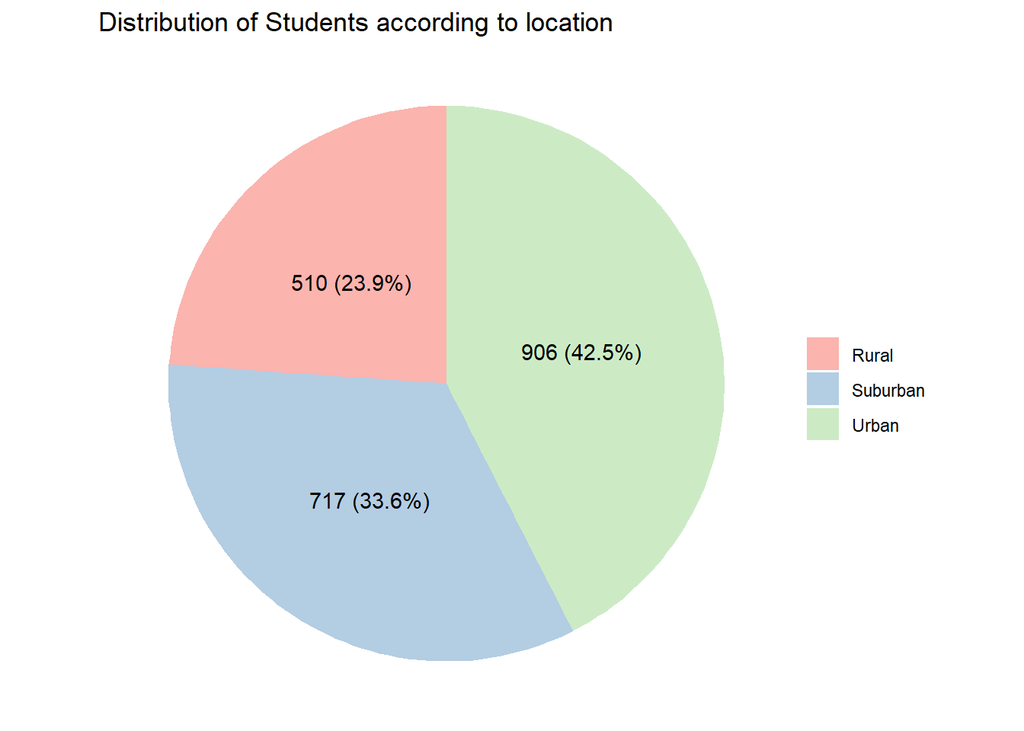

```r
school_set %>% count() %>% ggplot(aes(x="",y=c(school_set$n), fill=school_setting)) +
  geom_bar(stat="identity", width=1) +
  coord_polar("y",start=0) +
  theme_void() +
  labs(title= "Distribution of Students according to location") +
  theme(legend.title=element_blank()) +
  geom_text(aes(label=paste0(school_set$n," (",scales::percent(school_set$n/sum(school_set$n)),")")),position = position_stack(vjust=0.5)) +
  scale_fill_brewer(palette="Pastel1")
```

We can infer that 42.5% of the total students study in Urban areas with a count of 906, 33.6% students study in Suburban areas, whereas 23.9% students study in Rural areas.

We have further calculated the mean of pre-test and post-test scores of students according to the location of the school.

```r
mean_set <- mydata %>% select(school_setting,pretest,posttest) %>% group_by(school_setting) %>% summarise(pretest_set=mean(pretest), posttest_set=mean(posttest))
mean_set
```

```
## # A tibble: 3 x 3
##   school_setting pretest_set posttest_set
##   <chr>                <dbl>        <dbl>
## 1 Rural                 51.5         64.1
## 2 Suburban              63.8         76.0
## 3 Urban                 49.9         61.7
```

```r
mean_set_tidy <- mean_set %>% pivot_longer(cols=c(pretest_set,posttest_set))
mean_set_tidy
```

```
## # A tibble: 6 x 3
##   school_setting name         value
##   <chr>          <chr>        <dbl>
## 1 Rural          pretest_set   51.5
## 2 Rural          posttest_set  64.1
## 3 Suburban       pretest_set   63.8
## 4 Suburban       posttest_set  76.0
## 5 Urban          pretest_set   49.9
## 6 Urban          posttest_set  61.7
```

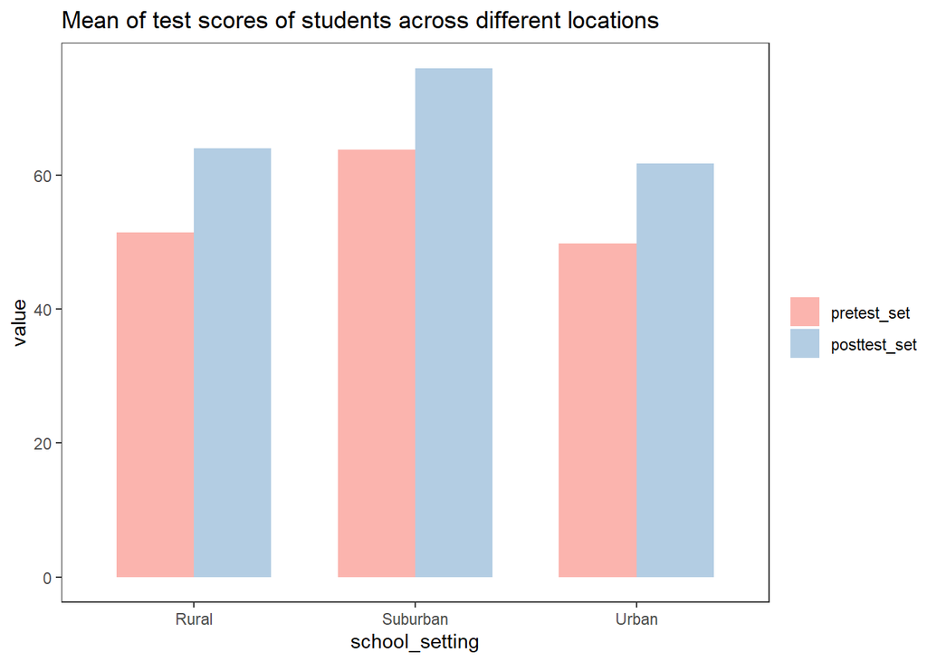

```r
mean_set_tidy %>% ggplot(aes(fill=factor(name, levels = c('pretest_set','posttest_set')), x= school_setting, y=value)) +
    geom_col(position = "dodge", width=0.7) +
  labs(title= "Mean of test scores of students across different locations") +
  theme_test() +
  theme(legend.title = element_blank()) +
  scale_fill_brewer(palette = "Pastel1")
```

We have plotted a grouped column chart for the same. We can infer that the students studying in Suburban areas have outperformed all the students studying in both Rural and Urban areas, both pre-test and post-test.

# School type

We have the grouprd the data in a way so that we can easily see the number of students going to each of public and non-public schools.

```r
type_school <- group_by(mydata,school_type) %>% count()
type_school
```

```
## # A tibble: 2 x 2
## # Groups:   school_type [2]
##   school_type     n
##   <chr>       <int>
## 1 Non-public    551
## 2 Public       1582
```

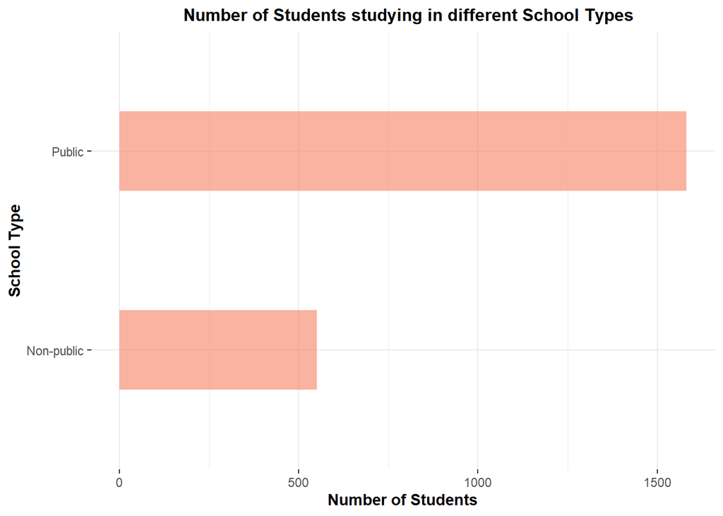

```r
type_school %>% ggplot(aes(x=school_type, y=n)) +
  geom_bar(stat="identity", fill= "#f68060", alpha=0.6, width=0.4) +
  coord_flip() +
  theme_ggstatsplot() +
  labs(y="Number of Students", x="School Type", title = "                   Number of Students studying in different School Types")
```

In the barplot with which we have visualised the above mentioned and calculated data, we can see that the number of students studying in public schools is approximately thrice the number of students studying in non-public schools.

```r
mean_type <- mydata %>% select(school_type,pretest,posttest) %>% group_by(school_type) %>% summarise(pretest_type=mean(pretest), posttest_type=mean(posttest))
mean_type
```

```
## # A tibble: 2 x 3
##   school_type pretest_type posttest_type
##   <chr>              <dbl>         <dbl>
## 1 Non-public          63.3          76.0
## 2 Public              52.1          64.0
```

```r
mean_type_tidy <- mean_type %>% pivot_longer(cols=c(pretest_type,posttest_type))
mean_type_tidy
```

```
## # A tibble: 4 x 3
##   school_type name          value
##   <chr>       <chr>         <dbl>
## 1 Non-public  pretest_type   63.3
## 2 Non-public  posttest_type  76.0
## 3 Public      pretest_type   52.1
## 4 Public      posttest_type  64.0
```

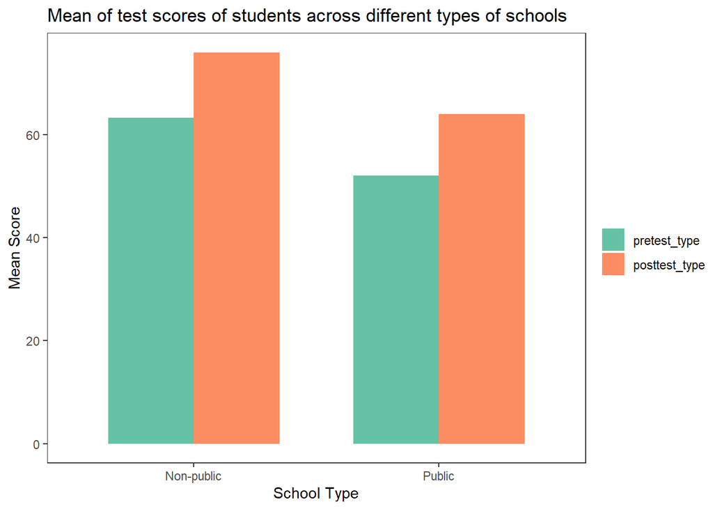

```r
mean_type_tidy %>% ggplot(aes(fill=factor(name, levels = c('pretest_type','posttest_type')), x= school_type, y=value)) +
    geom_col(position = "dodge", width=0.7) +
  labs(title= "Mean of test scores of students across different types of schools") +
  theme_test() +
  theme(legend.title = element_blank()) +
  labs(x="School Type",y="Mean Score") +
  scale_fill_brewer(palette = "Set2")
```

When plotting the mean of pre-test and post-test scores of students as per the type of school, we can see, that though the number of students in public schools is almost thrice of the students in non-public schools, still the students in non-public schools perform better.

# Teaching Method

We have tried to visualise and analyse the number of students undergoing different types of teaching methods, and its effects on the scoring capabilities of students.

```r
teaching <- group_by(mydata,teaching_method) %>% count()
teaching
```

```
## # A tibble: 2 x 2
## # Groups:   teaching_method [2]
##   teaching_method     n
##   <chr>           <int>
## 1 Experimental      760
## 2 Standard         1373
```

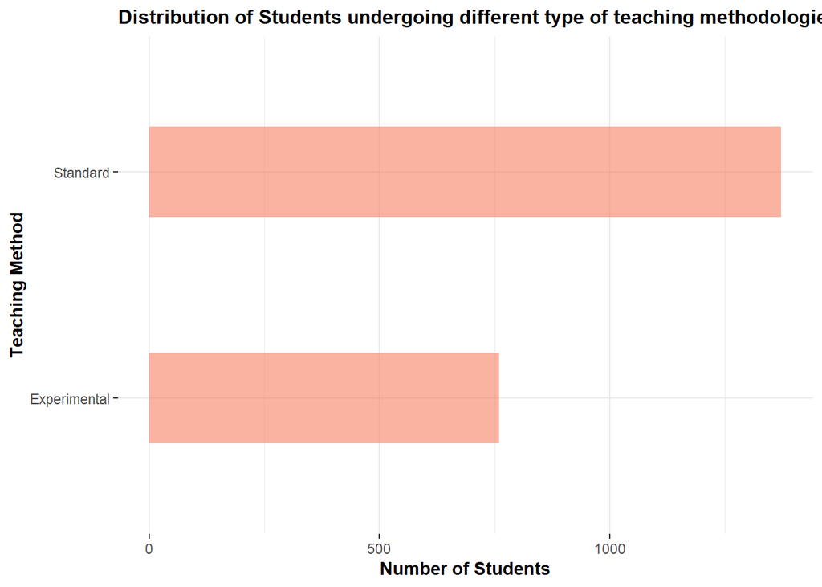

```r
teaching %>% ggplot(aes(x=teaching_method, y=n)) +
  geom_bar(stat="identity", fill= "#f68060", alpha=0.6, width=0.4) +
  coord_flip() +
  theme_ggstatsplot() +
  labs(y="Number of Students", x="Teaching Method", title = "Distribution of Students undergoing different type of teaching methodologies")
```

```r
mean_teach <- mydata %>% select(teaching_method,pretest,posttest) %>% group_by(teaching_method) %>% summarise(pretest_teach=mean(pretest), posttest_teach=mean(posttest))
mean_teach
```

```
## # A tibble: 2 x 3
##   teaching_method pretest_teach posttest_teach
##   <chr>                   <dbl>          <dbl>
## 1 Experimental             57.1           73.0
## 2 Standard                 53.8           63.8
```

```r
mean_teach_tidy <- mean_teach %>% pivot_longer(cols=c(pretest_teach,posttest_teach))
mean_teach_tidy
```

```
## # A tibble: 4 x 3
##   teaching_method name           value
##   <chr>           <chr>          <dbl>
## 1 Experimental    pretest_teach   57.1
## 2 Experimental    posttest_teach  73.0
## 3 Standard        pretest_teach   53.8
## 4 Standard        posttest_teach  63.8
```

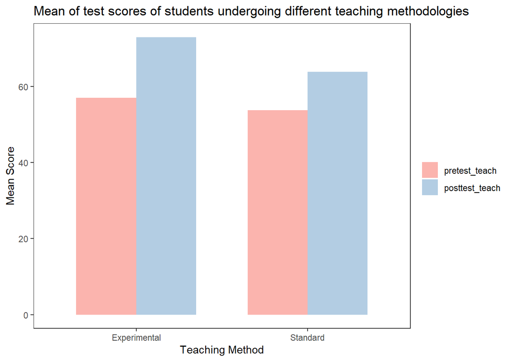

```r
mean_teach_tidy %>% ggplot(aes(fill=factor(name, levels = c('pretest_teach','posttest_teach')), x= teaching_method, y=value)) +
    geom_col(position = "dodge", width=0.7) +
  labs(x="Teaching Method", y="Mean Score" , title= "Mean of test scores of students undergoing different teaching methodologies") +
  theme_test() +
  theme(legend.title = element_blank()) +
  scale_fill_brewer(palette = "Pastel1")
```

We can further infer that experimental teaching provides better results than standard methods of teaching, and improvement in scores is also more in experimental, when compared across pre-test and post-test scores.

# Gender

We have tried to explore and visualise the gender distribution in schools.

```r
gender_st <- group_by(mydata,gender) %>% count()
gender_st
```

```
## # A tibble: 2 x 2
## # Groups:   gender [2]
##   gender     n
##   <chr>  <int>
## 1 Female  1056
## 2 Male    1077
```

```r
genderwise_schoolwise <- mydata %>% select(school,gender) %>% group_by(school,gender) %>% count()
genderwise_schoolwise
```

```
## # A tibble: 46 x 3
## # Groups:   school, gender [46]
##    school gender     n
##    <chr>  <chr>  <int>
##  1 ANKYI  Female    20
##  2 ANKYI  Male      21
##  3 CCAAW  Female    69
##  4 CCAAW  Male      40
##  5 CIMBB  Female    37
##  6 CIMBB  Male      37
##  7 CUQAM  Female    43
##  8 CUQAM  Male      64
##  9 DNQDD  Female    53
## 10 DNQDD  Male      69
## # ... with 36 more rows
```

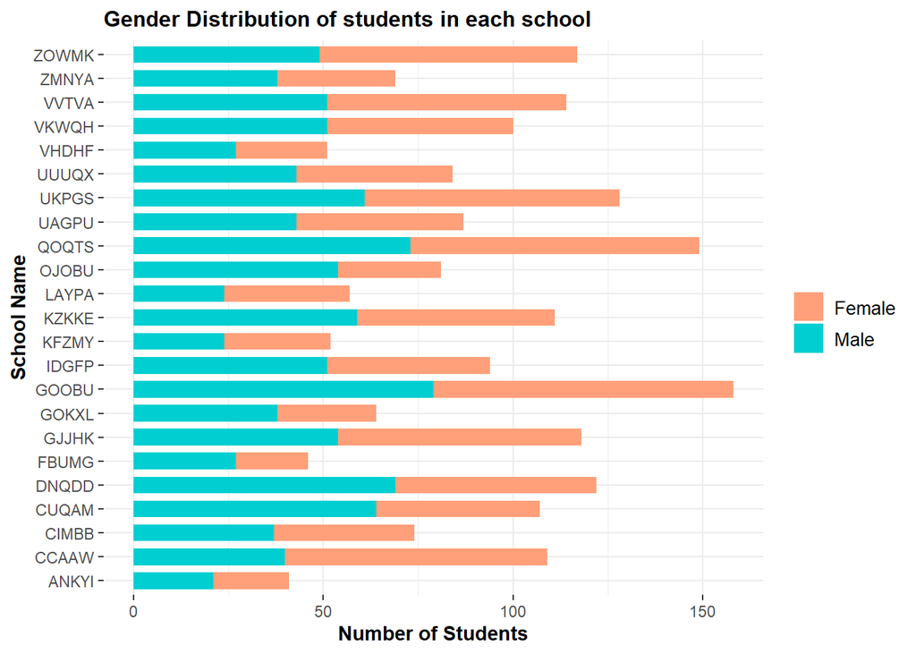

```r
genderwise_schoolwise %>% ggplot(aes(x=school, y=n, fill=factor(gender, levels = c('Female','Male')))) +
  geom_bar(stat="identity",width=0.7) +
  coord_flip() +
  theme_ggstatsplot() +
  theme(legend.title = element_blank()) +
  labs(x="School Name",y="Number of Students", title="Gender Distribution of students in each school") +
  scale_fill_manual(values = c("lightsalmon","darkturquoise"))
```

# Pretest and Posttest

We have explored the pre-test and post-test columns of the data sets. The **summary()** function provides us with each of the baisc details for each of them, such as minimum, maximum, quartiles, mean and median.

```r
summary(mydata$pretest)
```

```
##    Min. 1st Qu.  Median    Mean 3rd Qu.    Max.
##   22.00   44.00   56.00   54.96   65.00   93.00
```

```r
summary(mydata$posttest)
```

```
##    Min. 1st Qu.  Median    Mean 3rd Qu.    Max.
##    32.0    56.0    68.0    67.1    77.0   100.0
```

```r
pre_post <- mydata %>% select(pretest,posttest) %>% pivot_longer(cols=c(pretest,posttest))
pre_post
```

```
## # A tibble: 4,266 x 2
##    name     value
##    <chr>    <dbl>
##  1 pretest     62
##  2 posttest    72
##  3 pretest     66
##  4 posttest    79
##  5 pretest     64
##  6 posttest    76
##  7 pretest     61
##  8 posttest    77
##  9 pretest     64
## 10 posttest    76
## # ... with 4,256 more rows
```

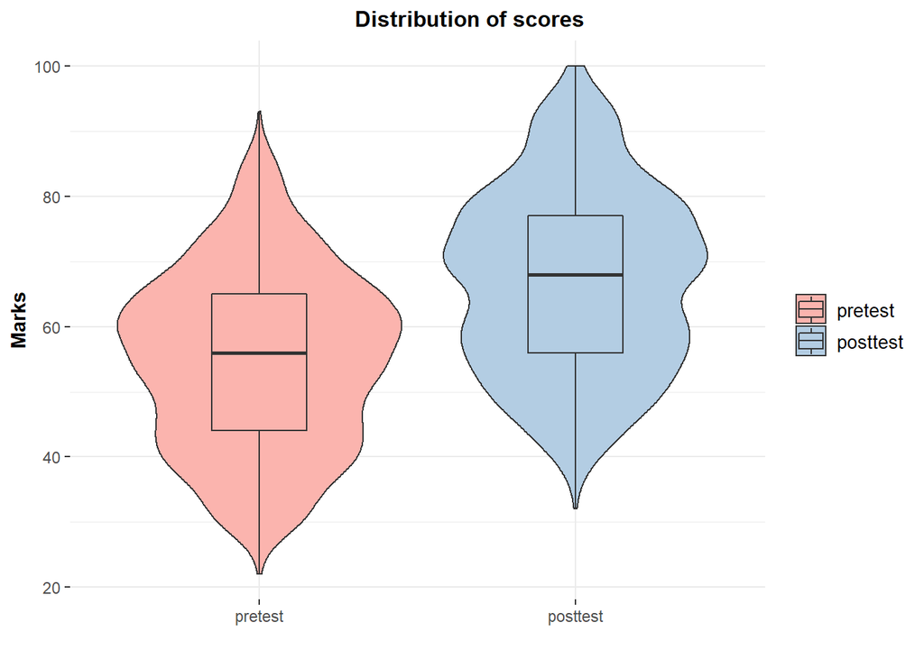

```r
pre_post %>% ggplot(aes(x=factor(name, levels = c('pretest','posttest')), y=value, fill=factor(name, levels = c('pretest','posttest')))) +
  geom_violin() +
  geom_boxplot(width=0.3) +
  labs(x="",y="Marks", title="                                              Distribution of scores") +
  theme_ggstatsplot() +
  theme(legend.title = element_blank()) +
  scale_fill_brewer(palette="Pastel1")
```

```r
pre_post_scatter <- mydata %>% select(pretest,posttest)
head(pre_post_scatter)
```

```
##   pretest posttest
## 1      62       72
## 2      66       79
## 3      64       76
## 4      61       77
## 5      64       76
## 6      66       74
```

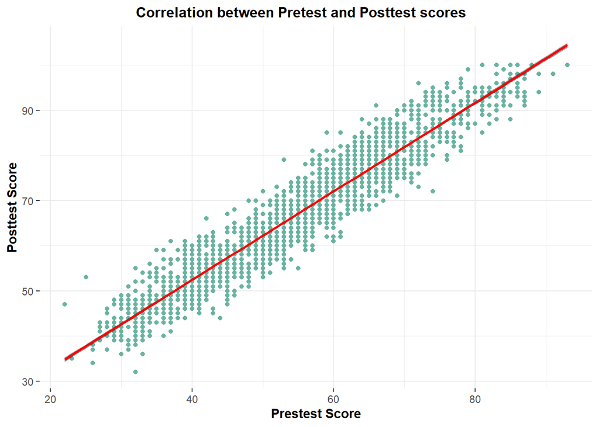

```r
pre_post_scatter %>% ggplot(aes(x=pretest, y=posttest)) +
  geom_point(color="#69b3a2") +
  theme_ggstatsplot() +
  geom_smooth(method=lm, color="red", fill="369b3a2", se=TRUE) +
  labs(x="Prestest Score", y="Posttest Score", title="                        Correlation between Pretest and Posttest scores")
```

Since now we have an idea that students are improving their scores from pre-test to post-test, we have plotted a scatterplot to visualise the correlation between the two fields. We have further plotted the line of best fit to the distribution, using which, we can even make an approximate guess of how much a student will score in post-test if we have their pre-test scores known.

# Conclusion

After exploring a data of 2133 students, over 11 parameters(columns), we can say, many of the parameters make a difference to how well a student performs in pre-test, and their scope of improvement in pre-test score to post-test scores.

- A student studying in sub-urban non-public school will perform better than the one studying in rural public schools. This could be because of many reasons, including facilities, but that is not of our concern in this Exploratory Data Analysis project.
- No gender bias can be seen in schools.
- And, experimental teaching methods result in better result an improvement when compared to traditional(standard) methods of teaching.
- A high majority of the students’ score improve in post-test from pre-test.